# 201A_Week1_Lecture notes

TAO XU

2025-10-17

## Motivation for Measure Theory

**Key question:**

How can we rigorously define the *“total size”* — length, area, or volume — of an **arbitrary** set  
$E \subset \mathbb{R}^d$?

## Goal

Formally, we want to construct a function
$$\mu : \mathcal{P}(\mathbb{R}^d) \to [0, +\infty]$$
where $\mathcal{P}(\mathbb{R}^d)$ denotes the **power set** of $\mathbb{R}^d$.

This function $\mu$ should assign to each set $E \subset \mathbb{R}^d$ a number that represents its *measure* or *total size*.

## Conceptual Idea

We want to generalize the familiar notions of:

**Length** for subsets of $\mathbb{R}$

**Area** for subsets of $\mathbb{R}^2$

**Volume** for subsets of $\mathbb{R}^3$

## Defining Properties of a Measure $\mu$

A measure $\mu$ on $\mathbb{R}^d$ should satisfy the following properties:

### **1. Correct size for simple sets**

For simple geometric sets, the measure agrees with the intuitive notion of length, area, or volume.
For example, in one dimension ($d=1$):
$$\mu([a,b]) = b - a, \quad \text{for } a \le b.$$

### **2. Finite additivity**

If $\{E_i\}_{i=1}^n \subseteq \mathbb{R}^d$ are **disjoint**, then
$$\mu\left(\bigcup_{i=1}^n E_i\right)
= \sum_{i=1}^n \mu(E_i).$$

### **3. Countable additivity (σ-additivity)**

If $\{E_i\}_{i=1}^{\infty} \subseteq \mathbb{R}^d$ are **disjoint**, then
$$\mu\left(\bigcup_{i=1}^{\infty} E_i\right)
= \sum_{i=1}^{\infty} \mu(E_i).$$

This property distinguishes a true **measure** from a finitely additive set function.

### **4. Translation invariance**

For all sets $E \subseteq \mathbb{R}^d$ and all vectors $c \in \mathbb{R}^d$,
$$\mu(E + c) = \mu(E),$$
where
$$E + c = \{x + c : x \in E\}.$$

This means that “shifting” a set in space does not change its measure.

## Measuring the “Area Under a Function”

An important kind of *set* we want to measure is the **area under a function**:

$$\int f(x)\,dx$$

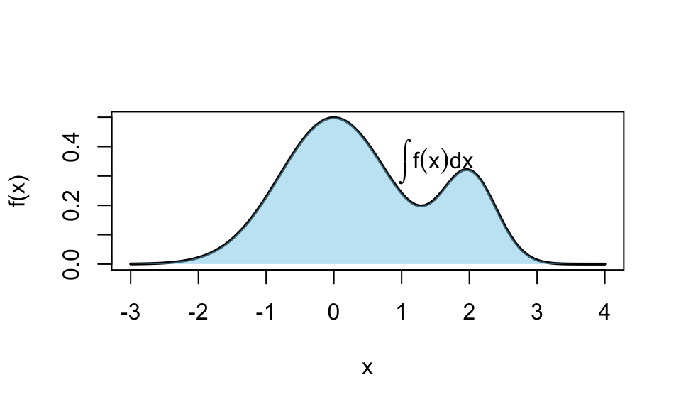

## Pre-Measure Theory: The Riemann Integral

Before the modern theory of measure (mid-1800s),

the **Riemann integral** provided a rigorous definition of the integral of piecewise continuous functions

defined in terms of **upper and lower sums**.

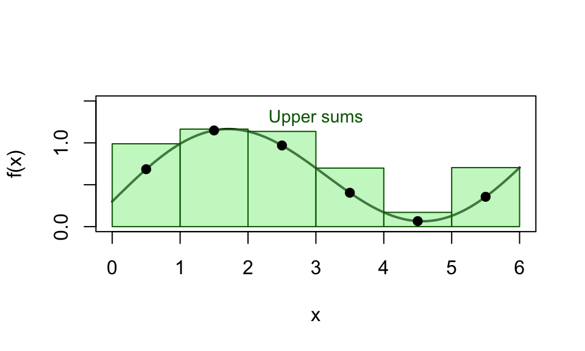

### **Interpretation**

The **Riemann integral** approximates area by dividing the domain into finitely many intervals and summing up **rectangles**.

Measure theory generalizes this process to arbitrary sets and functions, removing the limitations of Riemann integration.

## Riemann Integration: Strengths and Limitations

### ✅ **Pros**

Good enough for **“ordinary”** functions — smooth, piecewise continuous, or well-behaved curves.

### ❌ **Cons**

Not sufficient for **“unusual”** functions or when dealing with **limits of functions**.

**Example (Dirichlet function):**
$$f(x) =
\begin{cases}
1, & x \in \mathbb{Q},\\[4pt]
0, & x \in \mathbb{R}\setminus\mathbb{Q}.
\end{cases}$$

This function is *discontinuous everywhere*, so it is **not Riemann integrable** on any interval

yet intuitively, it “should” have total size zero because the rationals are countable.

### **Problem: Taking limits of functions**

Suppose we have a sequence of functions
$$f_n : [a,b] \to \mathbb{R}, \quad n \in \mathbb{N}$$
s.t.
$$\lim_{n\to\infty} f_n(x) = f(x) \quad \forall x \in [a,b]$$

**Question:**  
When can we interchange the limit and the integral?

$$\lim_{n\to\infty} \int_a^b f_n(x)\,dx \;=\; \int_a^b f(x)\,dx \;?$$

This is the key issue that Riemann integration cannot handle well —it fails for many pointwise convergent sequences.

## Measure Theory vs. Riemann Integration

Measure theory provides a **more powerful and general theory of integration** than the Riemann integral.

### ✅ **Pros of Measure Theory**

Can integrate a **much larger class of functions**, including highly irregular or discontinuous ones.

**Better suited to taking limits** — e.g., supports limit theorems such as Monotone Convergence and Dominated Convergence.

**Fundamental framework** for modern analysis:  
used in **probability**, **functional analysis**, and **partial differential equations (PDEs)**.

### ❌ **Cons**

None 🙂

## Back to Our Goal

We begin with the one-dimensional case $d = 1$.

### **Theorem (Vitali, 1905)**

There does **not** exist a function
$$\mu : \mathcal{P}(\mathbb{R}) \to [0, +\infty]$$
that satisfies all of the following:

1. $\mu([a,b]) = b - a$ for all $a \le b$;
2. $\mu$ is **countably additive**;
3. $\mu$ is **translation invariant**.

In other words, **no measure can be defined on *all* subsets of** $\mathbb{R}$ that behaves like length and respects these natural properties.

This result is known as the **Vitali theorem**, and it motivates the need to restrict our attention to *measurable* subsets of $\mathbb{R}$.

### **Lemma (Monotonicity)**

Let $X$ be a set and let
$$\mu : \mathcal{P}(X) \to [0, +\infty]$$
be **finitely additive**.

Then for all subsets $A, B \subseteq X$,
$$A \subseteq B \quad \Rightarrow \quad \mu(A) \le \mu(B)$$

*Proof idea:*
If $A \subseteq B$, then $B = A \cup (B \setminus A)$ with disjoint union, so
$$\mu(B) = \mu(A) + \mu(B \setminus A) \ge \mu(A)$$

## Proof of the Lemma (Monotonicity)

Let $A, B \subseteq X$ with $A \subseteq B$.
Then
$$B = A \cup (B \setminus A),
\quad \text{where } (B \setminus A) = B \cap A^c$$

Using finite additivity:
$$\mu(B) = \mu(A) + \mu(B \setminus A) \ge \mu(A)$$
since measures are nonnegative.

Thus, $\mu(A) \le \mu(B)$.

## Proof of the Theorem (Vitali’s Theorem)

Assume, for contradiction, that such a measure $\mu : \mathcal{P}(\mathbb{R}) \to [0, +\infty]$ exists

which satisfies:

$\mu([a,b]) = b - a$ for all $a \le b$,

$\mu$ is **countably additive**,

$\mu$ is **translation invariant**.

### Step 1: Define an equivalence relation on $\mathbb{R}$

We define $x \sim y$ iff
$$x - y \in \mathbb{Q}.$$

That is, two real numbers are equivalent if their difference is **rational**.

For each $x \in \mathbb{R}$, define the **equivalence class**:
$$[x] = \{ y \in \mathbb{R} : y \sim x \}$$

So $[x]$ consists of all real numbers that differ from $x$ by a rational amount.

## Step 2. Selecting Representatives

### **Claim 1**

Every equivalence class (under $x \sim y \iff x - y \in \mathbb{Q}$)

contains at least one element in the interval $[0,1)$.

*(See HW 1, 6(a) for the proof.)*

### **Construction of the Vitali Set**

For each equivalence class, **choose one element** that lies in $[0,1)$.

Let $A$ be the set of all such chosen elements.

$$A = \{\, \text{one representative from each class in } [0,1) \,\}$$

This selection **requires the Axiom of Choice**, since the equivalence classes are uncountably many and disjoint.

**Warning:**  
The Vitali construction depends essentially on the **Axiom of Choice** (see *Bogachev, Measure Theory*, §1.12(x)).

### **Define translated copies**

For each rational $q \in \mathbb{Q} \cap [-1,1]$, define
$$A + q = \{\, a + q : a \in A \,\}$$

Let
$$B = \bigcup_{q \in \mathbb{Q} \cap [-1,1]} (A + q)$$

Intuitively, $B$ is the union of rational shifts of the Vitali set $A$ within $[-1,2]$.

## Step 3. Disjointness and Bounding

### **Claim 2**

The union
$$B = \bigcup_{q \in \mathbb{Q} \cap [-1,1]} (A + q)$$
is a **disjoint union**.
*(See HW 1, 6(b) for details.)*

### **Claim 3**

$$[0,1] \subseteq B \subseteq [-1,2]$$

#### (ii) Proof that $B \subseteq [-1,2]$:

Since $A \subseteq [0,1]$ and each $q \in \mathbb{Q} \cap [-1,1]$,
$$a + q \in [-1,2] \quad \forall a \in A$$
Hence $B \subseteq [-1,2]$.

#### (i) Proof that $[0,1] \subseteq B$:

For any $x \in [0,1]$, there exists $a \in A$ such that $x$ and $a$ are in the same equivalence class.

Then $x - a = q \in \mathbb{Q}$, and since $x, a \in [0,1]$, it follows that $q \in \mathbb{Q} \cap [-1,1]$.

Thus $x = a + q \in A + q \subseteq B.$

## Step 4. Contradiction

By the **monotonicity lemma** and the assumption that $\mu$ gives the “right size” to intervals:
$$1 = \mu([0,1]) \le \mu(B) \le \mu([-1,2]) = 3$$

However, by **countable additivity** and **translation invariance**:
$$\mu(B)
= \sum_{q \in \mathbb{Q} \cap [-1,1]} \mu(A + q)
= \sum_{q \in \mathbb{Q} \cap [-1,1]} \mu(A)$$

If $\mu(A) > 0$, then the sum diverges to $+\infty$.

If $\mu(A) = 0$, then $\mu(B) = 0$.

Either case contradicts $1 \le \mu(B) \le 3.$

$$\text{No such measure } \mu \text{ can exist.}$$

## Step 5. Discussion — Which Axiom to Weaken?

To construct a meaningful measure, we must **relax one of the assumptions**:

1. If we weaken **“right size for intervals”** or **translation invariance**,

   we lose compatibility with the intuitive notion of *length*.
2. If we weaken **countable additivity** to **finite additivity**,  
   some issues remain, especially for higher dimensions ($d \ge 3$).

## The Banach–Tarski Paradox (1924)

A striking consequence of the **Axiom of Choice** in higher dimensions.

### **Setup**

Let
$$U = \bigcup_{i=1}^{m} E_i,
\quad
V = \bigcup_{i=1}^{n} F_i,$$
where each $E_i, F_i \subset \mathbb{R}^3$.

Each $F_i$ is obtained from $E_i$ by a **rotation** or **translation** (i.e., an isometry of $\mathbb{R}^3$).

### **Statement**

It is possible to decompose a **solid ball** in $\mathbb{R}^3$ into finitely many disjoint pieces
$$U = \bigcup_{i=1}^{m} E_i$$
and then reassemble them using only **rotations and translations** to form **two identical copies** of the original ball:
$$V = \bigcup_{i=1}^{n} F_i$$

That is, one can “duplicate” a sphere using only rigid motions — **without stretching or adding volume**.

### **Interpretation**

This paradoxical result shows that **no countably additive, translation-invariant measure** (assigning finite, nonzero measure to 3D sets) can exist on *all* subsets of $\mathbb{R}^3$.

It relies crucially on the **Axiom of Choice** — the same principle used to construct Vitali sets.

## From the Vitali Theorem to Outer Measure

After seeing that a measure cannot be defined consistently on *all* subsets of $\mathbb{R}^d$, we have two reasonable paths forward:

### **Two Good Choices**

1. **Restrict the domain**:  
   Do not require $\mu$ to be defined on all of $\mathcal{P}(\mathbb{R}^d)$. Instead, define it only on a smaller, “nice” collection of subsets.
2. **Weaken countable additivity**:  
   Keep $\mu$ defined on all subsets, but replace **countable additivity** with **countable subadditivity**:

   $$\forall \{E_i\}_{i=1}^{\infty}, \quad
   \mu\left(\bigcup_{i=1}^{\infty} E_i\right)
   \le
   \sum_{i=1}^{\infty} \mu(E_i)$$

   Such a function is called an **outer measure**.

### **We Will See That…**

- Given a measure on “nice” subsets of $\mathbb{R}^d$, it can be **extended** to an outer measure on all of $\mathcal{P}(\mathbb{R}^d)$.
- Given an **outer measure**, we can identify a collection of “nice” sets on which it becomes a true **measure**.

## Measures and Algebras of Sets

To formalize this restriction, we need to specify what kind of subcollection of subsets we’ll use.

### **Definition (Algebra of Sets)**

Let $X$ be a set.  
A collection $\mathcal{A} \subseteq 2^X$ is called an **algebra of subsets of** $X$ if:

1. **Nonempty and closed under finite unions:**
   $$\{E_i\}_{i=1}^n \subseteq \mathcal{A}
   \;\Rightarrow\;
   \bigcup_{i=1}^n E_i \in \mathcal{A}$$
2. **Closed under complements:**
   $$E \in \mathcal{A} \;\Rightarrow\; E^c \in \mathcal{A}$$